# Assignment 6:

## Visualizing the correlation matrix

Create a visualization of the results of the correlation matrix.

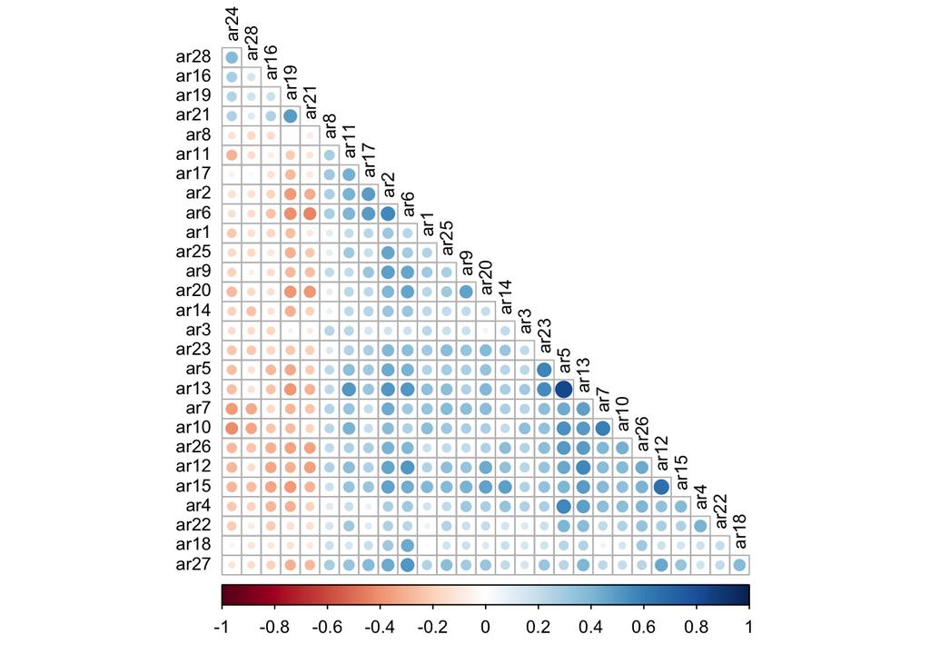

```r
corrplot::corrplot(
  ars_cor,
  method = "circle",
  type = "lower",
  order = "hclust",
  tl.col = "black",
  tl.cex = 0.8,
  diag = FALSE
)
```

## Test for factorability

Calculate the KMO score.

```r
kmo_result <- psych::KMO(ars_cor)

print(kmo_result)
```

```
## Kaiser-Meyer-Olkin factor adequacy
## Call: psych::KMO(r = ars_cor)
## Overall MSA =  0.88
## MSA for each item =
##  ar1  ar2  ar3  ar4  ar5  ar6  ar7  ar8  ar9 ar10 ar11 ar12 ar13 ar14 ar15 ar16
## 0.86 0.94 0.84 0.87 0.82 0.91 0.92 0.84 0.87 0.89 0.86 0.90 0.86 0.87 0.90 0.87
## ar17 ar18 ar19 ar20 ar21 ar22 ar23 ar24 ar25 ar26 ar27 ar28
## 0.83 0.74 0.88 0.92 0.83 0.90 0.87 0.85 0.90 0.94 0.88 0.77
```

## Test for multivariate normality

```r
ars_complete <- na.omit(ars_items)

mardia_result <- psych::mardia(ars_complete)
```

[figure not shown]

```r
print(mardia_result)
```

```
## Call: psych::mardia(x = ars_complete)
##
## Mardia tests of multivariate skew and kurtosis
## Use describe(x) the to get univariate tests
## n.obs = 150   num.vars =  28
## b1p =  235.5   skew =  5887.38  with probability  <=  1.3e-71
##  small sample skew =  6013.37  with probability <=  2.5e-80
## b2p =  920.52   kurtosis =  12.03  with probability <=  0
```

Test for skewness and kurtosis.

```r
normality_stats <- psych::describe(ars_items)

normality_stats[, c("skew", "kurtosis")]
```

```
##       skew kurtosis
## ar1  -0.05    -0.90
## ar2   0.64    -0.30
## ar3   1.77     3.31
## ar4   0.63    -0.06
## ar5   0.80     0.23
## ar6   0.79     0.31
## ar7   1.13     0.67
## ar8   0.94     0.32
## ar9  -0.55    -0.36
## ar10  1.36     2.22
## ar11  1.07     0.42
## ar12  0.20    -0.63
## ar13  0.92     0.81
## ar14  1.58     3.18
## ar15  0.15    -0.77
## ar16  0.11    -0.45
## ar17  0.03    -0.54
## ar18  0.98     1.49
## ar19 -0.52    -0.22
## ar20 -0.43    -0.21
## ar21 -0.66    -0.29
## ar22  0.98     1.16
## ar23  0.36    -0.85
## ar24 -0.17    -0.73
## ar25 -0.20    -0.61
## ar26  1.39     2.09
## ar27  0.48    -0.13
## ar28 -0.75    -0.18
```

## Create scree plot

Create a scree plot to help the decision on how many factors to include.

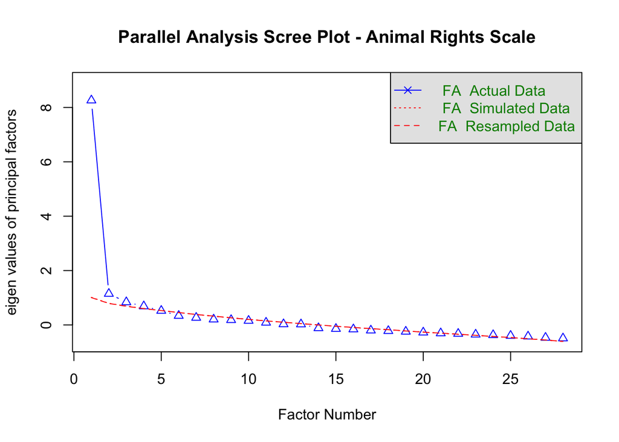

```
## Parallel analysis suggests that the number of factors =  4  and the number of components =  NA
```

```r
set.seed(123)

parallel_result <- psych::fa.parallel(
  ars_complete,
  fa = "fa",
  fm = "minres",
  n.iter = 100,
  main = "Parallel Analysis Scree Plot - Animal Rights Scale"
)
```

## Run the factor analysis

Run the factor analysis with the chosen number of factors.

```r
efa_4 <- psych::fa(
  ars_complete,
  nfactors = 4,
  fm = "minres",
  rotate = "oblimin",
  scores = "regression"
)
print(efa_4, cut = 0.30, sort = TRUE)
```

```
## Factor Analysis using method =  minres
## Call: psych::fa(r = ars_complete, nfactors = 4, rotate = "oblimin",
##     scores = "regression", fm = "minres")
## Standardized loadings (pattern matrix) based upon correlation matrix
##      item   MR1   MR2   MR4   MR3   h2   u2 com
## ar5     5  0.93                   0.82 0.18 1.0
## ar13   13  0.72                   0.74 0.26 1.2
## ar4     4  0.62                   0.44 0.56 1.3
## ar26   26  0.53                   0.44 0.56 1.2
## ar22   22  0.49                   0.25 0.75 1.0
## ar23   23  0.33                   0.35 0.65 2.2
## ar17   17        0.70             0.45 0.55 1.1
## ar6     6        0.64             0.67 0.33 1.6
## ar27   27        0.61             0.44 0.56 1.1
## ar2     2        0.61             0.57 0.43 1.2
## ar11   11        0.42             0.39 0.61 2.5
## ar9     9        0.42             0.35 0.65 2.1
## ar8     8        0.41             0.23 0.77 1.9
## ar18   18        0.36             0.24 0.76 2.8
## ar25   25                         0.26 0.74 2.3
## ar12   12                         0.49 0.51 3.5
## ar10   10              0.61       0.60 0.40 1.4
## ar7     7              0.60       0.52 0.48 1.1
## ar24   24             -0.59       0.42 0.58 1.5
## ar28   28             -0.46       0.21 0.79 1.1
## ar1     1              0.42       0.26 0.74 1.7
## ar3     3                         0.19 0.81 3.0
## ar21   21                   -0.61 0.43 0.57 1.0
## ar19   19                   -0.51 0.40 0.60 1.2
## ar20   20                    0.43 0.41 0.59 2.0
## ar15   15              0.30  0.33 0.53 0.47 3.1
## ar16   16                         0.21 0.79 2.3
## ar14   14                         0.21 0.79 3.7
##
##                        MR1  MR2  MR4  MR3
## SS loadings           3.52 3.44 2.66 1.92
## Proportion Var        0.13 0.12 0.10 0.07
## Cumulative Var        0.13 0.25 0.34 0.41
## Proportion Explained  0.30 0.30 0.23 0.17
## Cumulative Proportion 0.30 0.60 0.83 1.00
```

[output cut: 14 more lines]

```
## The root mean square of the residuals (RMSR) is  0.05
## The df corrected root mean square of the residuals is  0.06
##
## The harmonic n.obs is  150 with the empirical chi square  127.15  with prob <  1
## The total n.obs was  150  with Likelihood Chi Square =  370.6  with prob <  6.4e-05
##
## Tucker Lewis Index of factoring reliability =  0.898
## RMSEA index =  0.049  and the 90 % confidence intervals are  0.036 0.061
## BIC =  -992.3
## Fit based upon off diagonal values = 0.98
## Measures of factor score adequacy
##                                                    MR1  MR2  MR4  MR3
## Correlation of (regression) scores with factors   0.85 0.82 0.79 0.78
## Multiple R square of scores with factors          0.72 0.67 0.62 0.60
## Minimum correlation of possible factor scores     0.43 0.34 0.23 0.21
```

Sort the communality scores in decreasing order.

```r
communalities_sorted <- sort(
  efa_4$communality,
  decreasing = TRUE
)

print(round(communalities_sorted, 3))
```

```
##   ar5  ar13   ar6  ar10   ar2  ar15   ar7  ar12  ar17   ar4  ar27  ar26  ar21
## 0.823 0.742 0.670 0.602 0.570 0.531 0.518 0.487 0.446 0.443 0.439 0.439 0.426
##  ar24  ar20  ar19  ar11  ar23   ar9  ar25   ar1  ar22  ar18   ar8  ar14  ar28
## 0.418 0.414 0.401 0.388 0.355 0.352 0.265 0.264 0.255 0.245 0.228 0.212 0.208
##  ar16   ar3
## 0.206 0.188
```

Calculate the mean communality scores.

```r
mean_communality <- mean(efa_4$communality)

round(mean_communality, 3)
```

```
## [1] 0.412
```

Show the factor loadings for the chosen factor structure.

```r
loading_table <- as.data.frame(
  unclass(efa_4$loadings)
)

loading_table$item <- rownames(loading_table)
loading_table$h2 <- efa_4$communality

loading_table <- loading_table |>
  dplyr::relocate(item) |>
  dplyr::mutate(
    dplyr::across(where(is.numeric), ~ round(.x, 2))
  )

knitr::kable(
  loading_table,
  caption = "Four-factor pattern matrix and item communalities"
)
```

Four-factor pattern matrix and item communalities

|  | item | MR1 | MR2 | MR4 | MR3 | h2 |
| --- | --- | --- | --- | --- | --- | --- |
| ar1 | ar1 | -0.10 | 0.24 | 0.42 | 0.04 | 0.26 |
| ar2 | ar2 | 0.09 | 0.61 | 0.12 | 0.10 | 0.57 |
| ar3 | ar3 | 0.18 | 0.13 | 0.27 | -0.16 | 0.19 |
| ar4 | ar4 | 0.62 | -0.16 | 0.07 | 0.18 | 0.44 |
| ar5 | ar5 | 0.93 | -0.02 | 0.00 | -0.05 | 0.82 |
| ar6 | ar6 | 0.17 | 0.64 | -0.14 | 0.27 | 0.67 |
| ar7 | ar7 | 0.11 | 0.10 | 0.60 | 0.02 | 0.52 |
| ar8 | ar8 | 0.06 | 0.41 | 0.16 | -0.21 | 0.23 |
| ar9 | ar9 | -0.08 | 0.42 | 0.19 | 0.23 | 0.35 |
| ar10 | ar10 | 0.27 | 0.04 | 0.61 | -0.10 | 0.60 |
| ar11 | ar11 | 0.14 | 0.42 | 0.28 | -0.20 | 0.39 |
| ar12 | ar12 | 0.24 | 0.28 | 0.16 | 0.26 | 0.49 |
| ar13 | ar13 | 0.72 | 0.18 | 0.07 | -0.01 | 0.74 |
| ar14 | ar14 | 0.13 | 0.14 | 0.17 | 0.19 | 0.21 |
| ar15 | ar15 | 0.10 | 0.28 | 0.30 | 0.33 | 0.53 |
| ar16 | ar16 | -0.25 | 0.03 | -0.10 | -0.26 | 0.21 |
| ar17 | ar17 | -0.02 | 0.70 | 0.02 | -0.12 | 0.45 |
| ar18 | ar18 | 0.29 | 0.36 | -0.26 | -0.01 | 0.24 |
| ar19 | ar19 | -0.08 | -0.11 | -0.08 | -0.51 | 0.40 |
| ar20 | ar20 | -0.01 | 0.25 | 0.18 | 0.43 | 0.41 |
| ar21 | ar21 | -0.07 | -0.04 | 0.00 | -0.61 | 0.43 |
| ar22 | ar22 | 0.49 | 0.01 | -0.01 | 0.04 | 0.25 |
| ar23 | ar23 | 0.33 | 0.17 | 0.20 | 0.06 | 0.35 |
| ar24 | ar24 | -0.03 | 0.18 | -0.59 | -0.22 | 0.42 |
| ar25 | ar25 | 0.05 | 0.28 | 0.24 | 0.11 | 0.26 |
| ar26 | ar26 | 0.53 | 0.01 | 0.09 | 0.16 | 0.44 |
| ar27 | ar27 | 0.02 | 0.61 | -0.02 | 0.13 | 0.44 |
| ar28 | ar28 | 0.04 | 0.05 | -0.46 | -0.09 | 0.21 |

Visualize the factor structure.

```r
psych::fa.diagram(
  efa_4,
  cut = 0.40,
  digits = 2,
  cex = 0.7,
  main = "Four-Factor Structure of the Animal Rights Scale"
)
```

[figure not shown]